Gabriel Claret de Rezende

## Exercícios Conceituais

#### Questao 1

Aprendizagem de máquina nada mais é que o estudo de padrões entre variaveis relacionadas em um conjunto de dados.

#### Questao 2

Reconhecimento de padrões, classificação de emails spam, predições econômicas, entre outros.

#### Questao 3

Aprendizagem supervisionada é quando o conjunto de dados de entrada é rotulado e deseja-se encontrar uma função que seja capaz de predizer rótulos. Já a aprendizagem não supervisionada não há rotulos, e o objetivo é descobrir similaridades entre os objetos analisados.

#### Questao 4

São dados que já há um rótulo associado a eles, ou seja, já é conhecido o que aqueles dados são.

#### Questao 5

O modelo de ML é como se fosse uma equação para um problema na matemática, é um algoritmo com funções que permite fazer a predição de dados.

#### Questao 6

Algoritmo de Classificação.

#### Questao 7

Na aprendizagem online há sempre uma realimentação no modelo mesmo quando ele já esta ‘pronto’, podendo sempre evoluir. Já com a aprendizagem offline não existe essa realimentação.

#### Questao 8

Os parâmetros do modelo são as variáveis que a técnica de machine learning escolhida usa para ajustar os dados. E os hiperparâmetros são variáveis que controlam o próprio processo de treinamento.

#### Questao 9

Aprendizagem baseada em instâncias (instance-based): generalização realizada pelo modelo de ML é baseada em métricas de similaridade Aprendizagem baseada em modelos (model-based): as pressuposições sobre o domínio do problema são tratadas na forma de um modelo matemático.

#### Questao 10

É possivel que o modelo esteja sofrendo de overfitting com os dados de treinamento, ou seja, se enviesou para aqueles dados. Uma ferramente que pode contornar é a regularização, que adiciona à função custo o valor dos parâmetros.

## Exercícios Multipla Escolha

1. A
2. C
3. B
4. D
5. A
6. C
7. A
8. B
9. B
10. D

## Exercícios Computacionais

## Questao 1.

```r
# 1
df <- data.frame(
  id = c (1:5),
  Empresa = c("A","B","C","D","E"),
  Indices = c(500.3,530.2,630.5,400.20,940.20),
  Datas = as.Date(c("2020-03-05", "2020-04-21", "2020-12-10", "2020-10-15","2020-09-20")),
  stringsAsFactors = FALSE)

# 2
str(df)
```

```
## 'data.frame':    5 obs. of  4 variables:
##  $ id     : int  1 2 3 4 5
##  $ Empresa: chr  "A" "B" "C" "D" ...
##  $ Indices: num  500 530 630 400 940
##  $ Datas  : Date, format: "2020-03-05" "2020-04-21" ...
```

```r
# 3
subdf <- data.frame(df$Empresa, df$Indices)

# 4
array <- df[c(1,3),c(2,4)]

# 5
df3 <- df
df3$Setor <- c("it","adm","executive","rh","om")

# 6
dfn <- data.frame(
  id = c (6:10),
  Empresa = c("F","F","G","K","L"),
  Indices = c(1200.3,230.4,100.5,905.40,1100.50),
  Datas = as.Date(c("2020-09-10", "2020-07-08", "2020-10-15", "2020-06-07","2020-02-22")),
  stringsAsFactors = FALSE)

df_bind <- rbind(df, dfn)
df_bind
```

```
##    id Empresa Indices      Datas
## 1   1       A   500.3 2020-03-05
## 2   2       B   530.2 2020-04-21
## 3   3       C   630.5 2020-12-10
## 4   4       D   400.2 2020-10-15
## 5   5       E   940.2 2020-09-20
## 6   6       F  1200.3 2020-09-10
## 7   7       F   230.4 2020-07-08
## 8   8       G   100.5 2020-10-15
## 9   9       K   905.4 2020-06-07
## 10 10       L  1100.5 2020-02-22
```

## Questao 3.

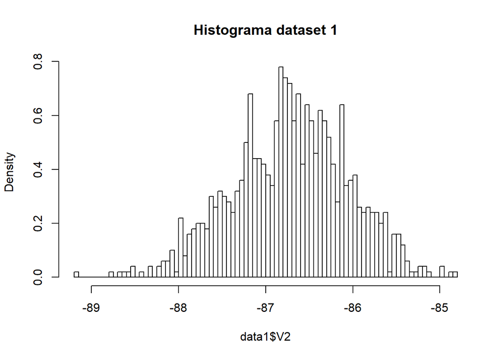

```r
library(ggplot2)
library(leaflet)

# 1
data1 <- read.delim("./datasets_lista_1/dataset_1.csv", skip = 20, sep = ',', header = FALSE)
data2 <- read.delim("./datasets_lista_1/dataset_2.csv", skip = 20, sep = ',', header = FALSE)

# 2 - Informações contidas no arquivo: Freq, SA Clear-Write, SA Blank, SA Blank, SA Blank

# 3

hist(data1$V2, probability = TRUE, breaks = 100, main = 'Histograma dataset 1')
```

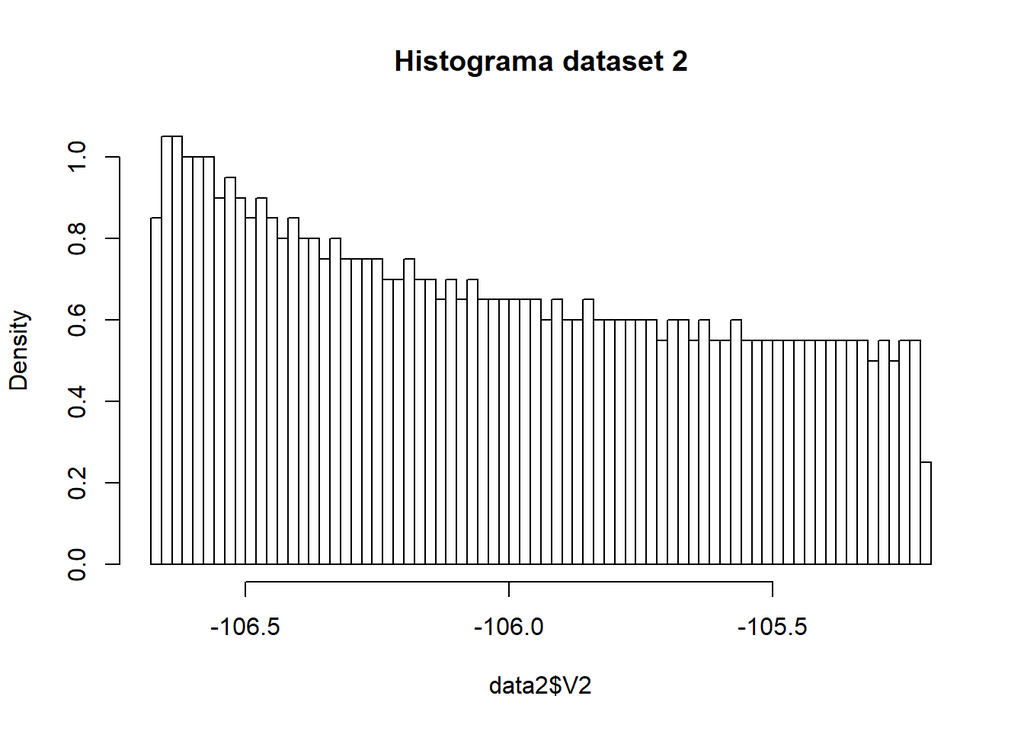

```r
hist(data2$V2, probability = TRUE, breaks = 100, main = 'Histograma dataset 2')
```

```r
# 4 # GPS Latitude: 22 15.40727 S
    # GPS Longitude: 45 41.74932 W

gps_lat = -22.25679
gps_long = -45.69582

leaflet() %>%
  addTiles() %>%
  addMarkers(lng = gps_long, lat = gps_lat,
             popup = 'ponto 1',
             clusterOptions = markerClusterOptions())
```

[interactive chart not shown]

## Questao 5.

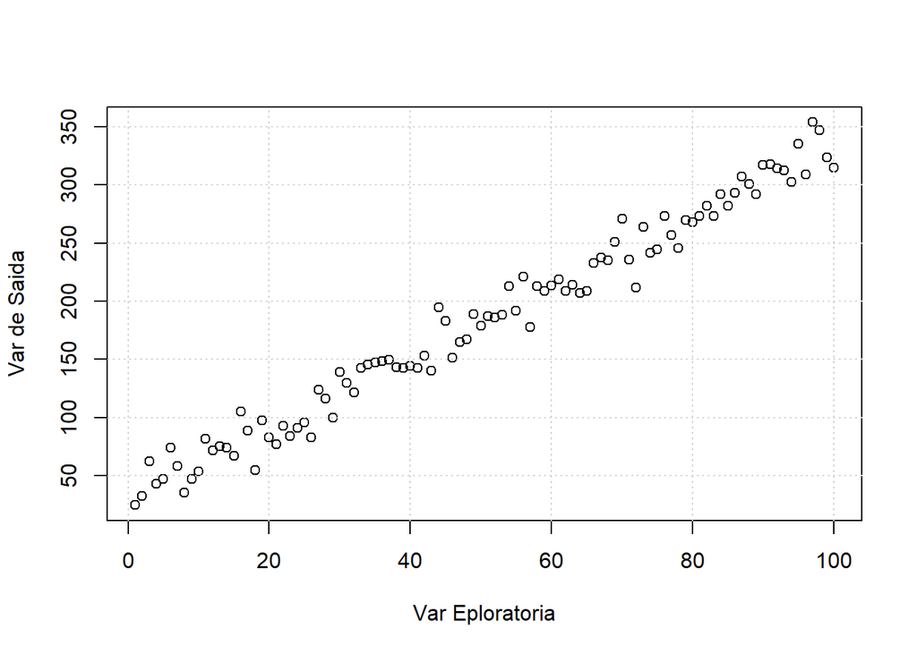

```r
# 1
x = seq(1, 100, length.out = 100)

h <- 3*x + 30

set.seed(123)
epsilon <- rnorm(100, 0, 15)

y <- h + epsilon

# 2
plot(x,y,col=1, pch=1,
     col.main = 'black',
     xlab = 'Var Eploratoria',
     ylab = 'Var de Saida')
grid()
```

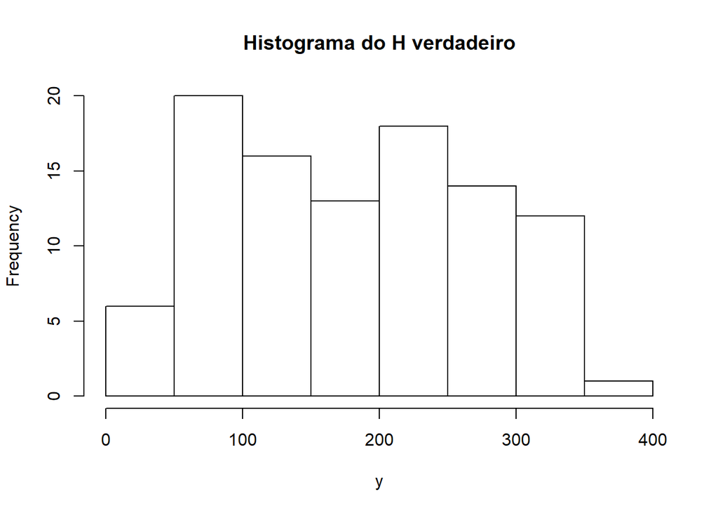

```r
h_estimado <- 2.8*x + 32
y2 <- h_estimado + epsilon
# 3

hist(y, main = 'Histograma do H verdadeiro')
```

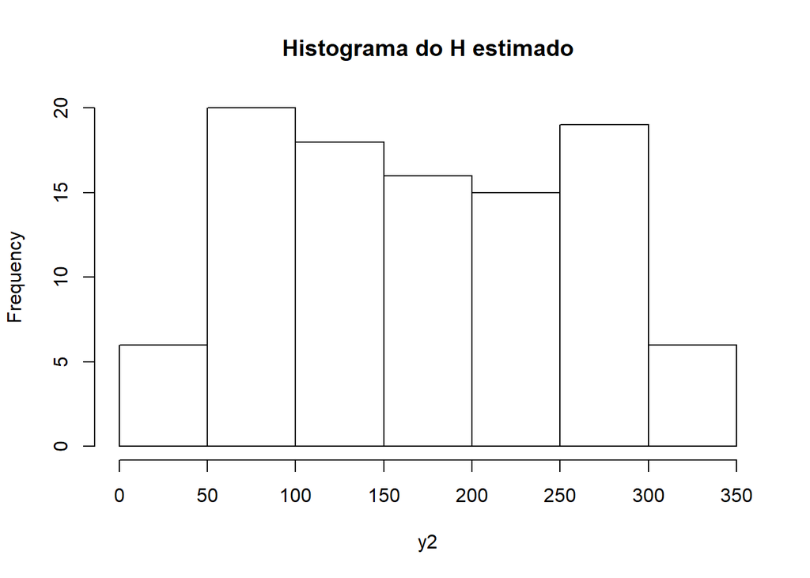

```r
hist(y2, main = 'Histograma do H estimado')
```

```r
# 4 - MSE é uma métrica que é relacionada ao erro das predições do modelo

# 5
MSE = (1/100)*sum(((y - h_estimado)^2))
MSE
```

```
## [1] 320.9044
```

```r
# 6 - Sim, Depende do MSE e ele é relativamente baixo.
```

## Questao 7.

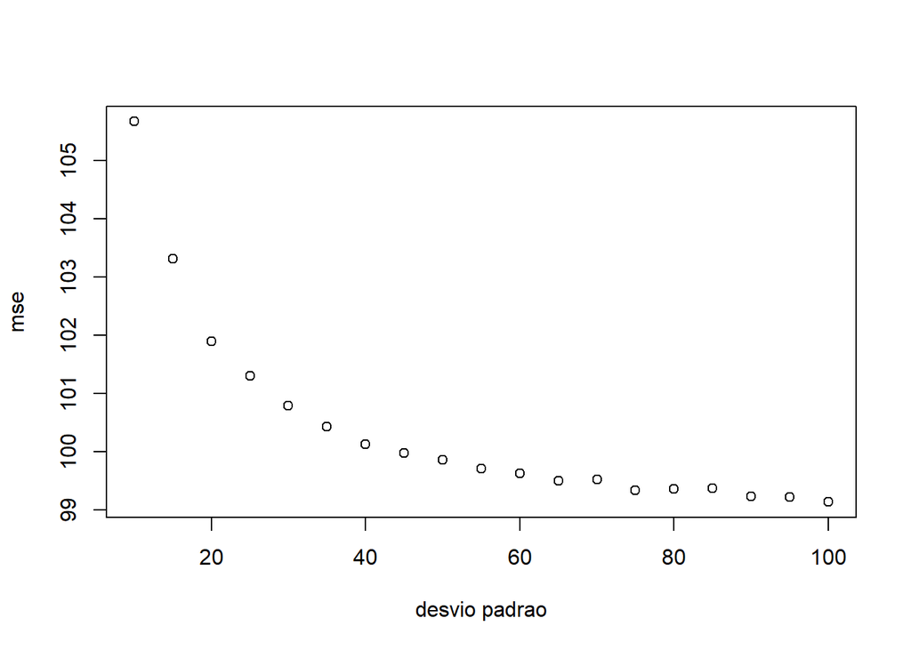

```r
# 1
x = seq(1, 100, length.out = 100)

n_vector = seq(10, 100, 5)

mse_vector = rep(0,length(n_vector))
mse = rep(0, 1000)

for (i in 1:length(n_vector)){
  n = n_vector[i]
  x = seq(1, 100, length.out = n)
  h_x <- 3*x + 30

  for (j in 1:1000){

    e <- rnorm(n, 0, 0.5)
    y <- h_x + e
    h_est <- 2.8*x + 32

    mse[j] = (1/n)*sum(((y - h_est)^2))
  }
  mse_vector[i] = mean(mse)
}

# 2
plot(x = n_vector, y = mse_vector, xlab = 'desvio padrao', ylab ='mse', type = 'p')
```

## Questao 8.

```r
library(quantmod)
library(xts)
library(moments)


# 1
getSymbols("PETR4.SA", src = "yahoo", from = "2020-01-01", to = "2020-06-29")
```

```
## [1] "PETR4.SA"
```

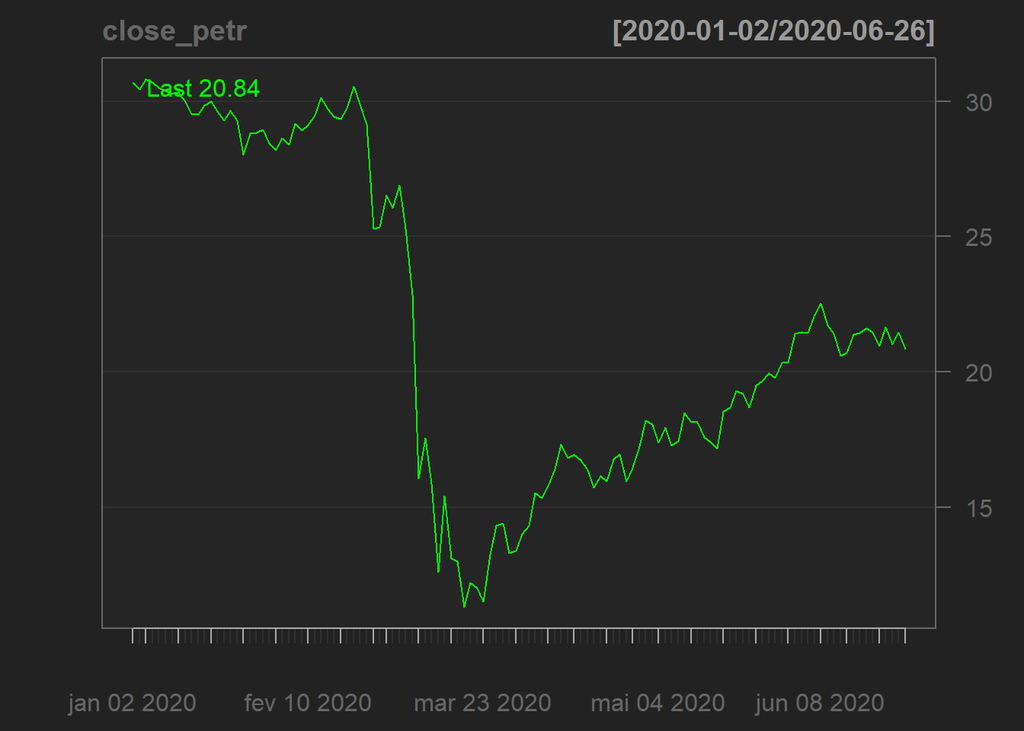

```r
# 2
st_petr = na.omit(PETR4.SA)

close_petr <- st_petr$PETR4.SA.Close

candleChart(close_petr)
```

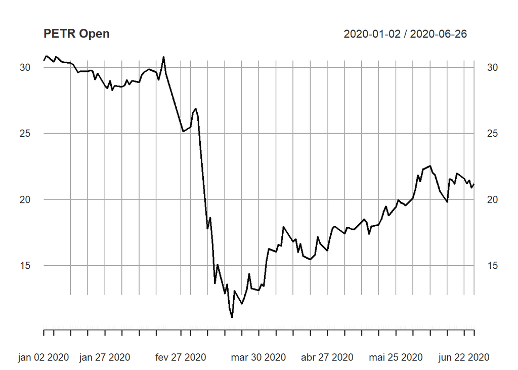

```r
# 3
plot(st_petr$PETR4.SA.Open, main = "PETR Open", xlab = "Tempo", ylab = "Valor")
```

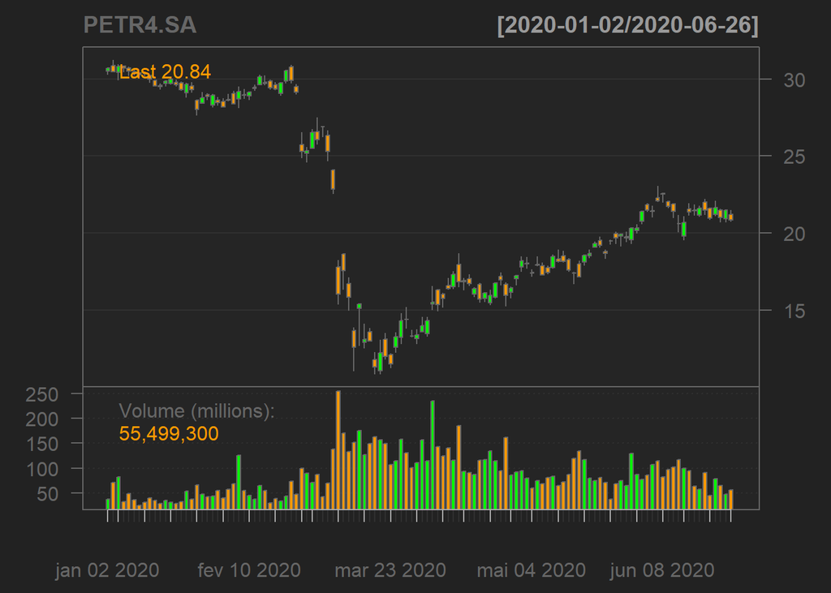

```r
candleChart(PETR4.SA)
```

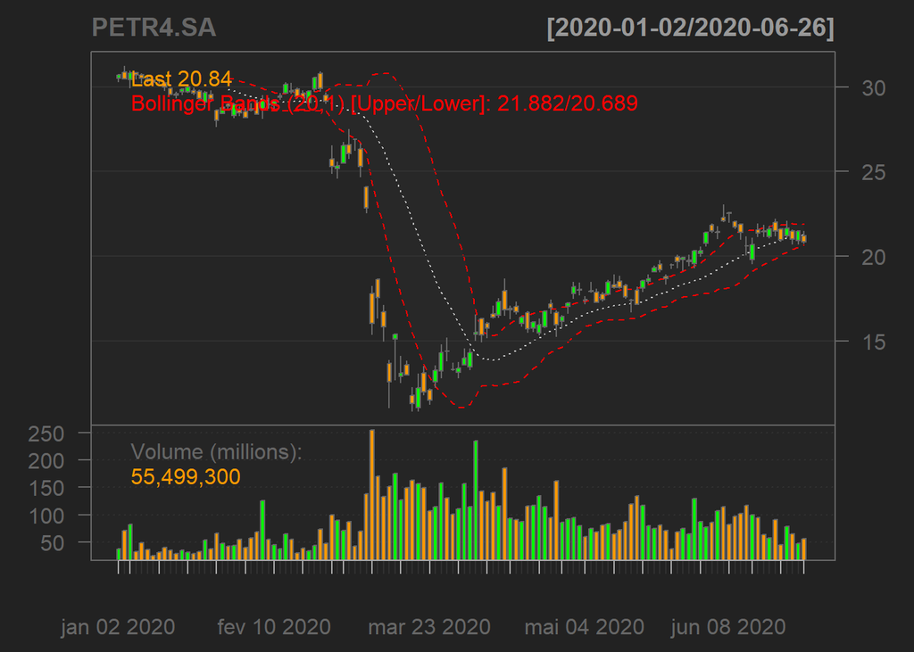

```r
# 4
addBBands(20, 1)
```